# Lesson 13: Inference for Two Means (Independent Samples)

Preparation

- Word Document
- PDF Document

## Solutions

Problem

Part

Solution

1

-

There is no pairing between the two groups. Group 1 does not determine Group 2.

2

-

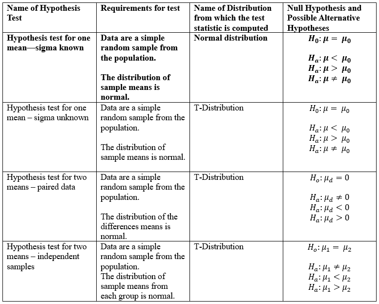

3

A

Is there a difference between the mean wages of BYU-Idaho male students and female students?

3

B

$H_o: \mu_1 = \mu_2$  
$H_a: \mu_1 \neq \mu_2$

4

-

Students from one of the Math Department professor’s classes took a survey which asked how much they make as an hourly wage.

5

-

-Males: $\bar{x} =11.935$, $s=10.491$, $n=85$  
- Females: $\bar{x}=9.759$, $s=3.169$, $n=91$  
- You should also include two histograms here, one for the men and one for the women.

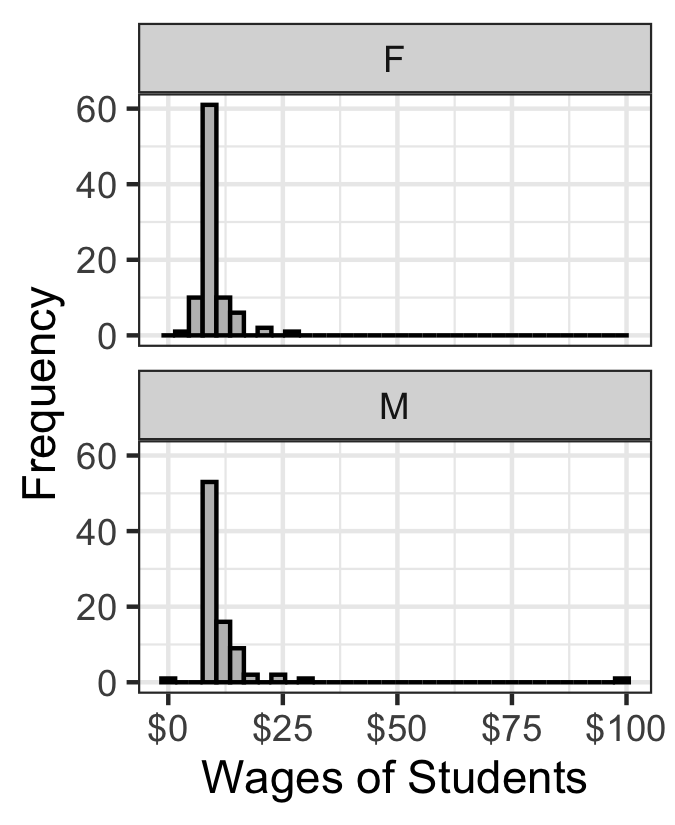

6

A

Independent Samples Hypothesis test

6

B

-The sample size is large for each sample so we can assume normality.  
- It was not a simple random sample.

6

C

$t= \pm 1.836$

6

D

$df = 98.263$

6

E

$\text{P-value} = 0.069$, $\alpha = 0.05$, $\text{p-value} > \alpha$

6

F

fail to reject the null hypothesis

6

G

We have insufficient evidence to say that there is a difference between wages of male and female BYU-Idaho students.

6

H

(-0.176, 4.529) or (-4.529, 0.176)

6

I

-We are 95% confident that the true difference in mean wages between women and men at BYU-Idaho is somewhere between $-0.18 and $4.53, or $-4.53 and $0.18.  
- We can also see that there is insufficient evidence using the confidence interval method because zero is included in our confidence interval.

7

Answers may vary